# Walmart Retail Sales Analysis

Ryan Standridge

[figure not shown]

# 1 Introduction

One of the leading retail stores in the US, Walmart, would like to predict the sales and demand accurately. There are certain events and holidays which impact sales on each day. There are sales data available for 45 stores of Walmart. The business is facing a challenge due to unforeseen demands and runs out of stock for some weeks (Kaggle).

Walmart runs several promotional markdown events throughout the year. These markdowns precede prominent holidays, the four largest of all, which are the Super Bowl, Labour Day, Thanksgiving, and Christmas. The weeks including these holidays are weighted five times higher in the evaluation than non-holiday weeks (Kaggle).

In this project, I will be exploring the following questions:

1. What stores, on average, generate the most weekly sales for holiday weeks and non-holiday weeks? What stores generate the least on average?
2. Do holiday weeks generate more sales on average than non-holiday weeks?
3. Which stores have grown in weekly sales from year to year?
4. Which holidays have positive impacts on sales for each store?

I plan to address these questions of interest by first gathering the data from Kaggle, and then I will explore the data using descriptive statistics and graphs in RStudio. After the initial exploration, I will use MySQL Workbench to generate new tables that will be useful in finding insights for the questions of interest. Once these new datasets are created, I will transfer them to RStudio and visualize and analyze the data further, ultimately allowing me to offer solutions for Walmart.

# 2 Programs and Packages Used

The following programs were used in this analysis:

- MySQL Workbench
  - This program was using to manage the data and create tables (datasets) that are used for visualization and analysis in RStudio.
- RStudio
  - This program was used to import the datasets made from MySQL Workbench and create visuals and analysis of the Walmart Retail Sales dataset.

The following packages were used in this report:

- library(base):
  - This package comes with base R and allows me use many basic functions to retrieve data, create visuals, and perform analyses on the data sets.
  - There will be no warnings when loading this package since it comes with base R.
- library(dplyr):
  - This package allows me to manipulate data sets easier than base R.
  - Some warnings when loading the package ‘dplyr’:
    - Attaching package: ‘dplyr’
    - The following objects are masked from ‘package:stats’: filter, lag
    - The following objects are masked from ‘package:base’: intersect, setdiff, setequal, union

# 3 Data

The data for this project was collected from the website of Kaggle under the Data category (https://www.kaggle.com/vik2012kvs/walmart-dataretail-analysis). Once I found this dataset, I downloaded and saved the .csv file in my directory, allowing me to transfer the data set into SQL and then RStudio.

The original Walmart data frame contains 6435 rows in which each observation represents a statistic from 45 different stores over 143 different weeks (dates). Also, the data from contains 8 columns (variables):

This is dataset *Walmart* covers store sales from the dates of 2010-02-05 to 2012-11-01.

*Note: There are 48 weeks recorded in 2010 (from the week of Feb. 5, 2010 to Dec. 31, 2010), 52 weeks recorded in 2011 (all weeks throughout the year), and 43 weeks recorded in 2012 (from the first week of 2012 to Nov. 1, 2012).*

Each variable is described below:

: the store number

: the week of sales

: sales for the given store *Note: This variable will be used as the response*

: whether the week is a special holiday week 1 – Holiday week 0 – Non-holiday week

: Temperature on the day of sale

: Cost of fuel in the region

: Prevailing consumer price index

: Prevailing unemployment rate

Note: Holiday Dates are as follows:

Super Bowl: 12-Feb-10, 11-Feb-11, 10-Feb-12

Labour Day: 10-Sep-10, 9-Sep-11, 7-Sep-12

Thanksgiving: 26-Nov-10, 25-Nov-11

Christmas: 31-Dec-10, 30-Dec-11

*Data Source:* Kaggle (2020) https://www.kaggle.com/vik2012kvs/walmart-dataretail-analysis.

# 4 Cleaning data

After downloading the original *Walmart* dataset from Kaggle, I then created a schema in MySQL Workbench it then imported into a table. From there, I changed the format of the column to the form “YYYY-MM-DD”. Once this was done, I began creating queries that I thought would help answer the questions of interest. Once these queries were created, I then exported them to a .csv file in which I uploaded into RStudio. In RStudio, I then took a look at the dataset to see if there were any missing values and concluded that there were none. I then changed the column to be of type date since it was imported as a character variable. I then decided to create a new variable called which gives the dates integer values from 1 to 143 for each store in order to allow easier analysis across the dates.

**If you would like to see my SQL script from MySQL:** https://github.com/ryan-standridge/Walmart-Project-SQL-Script/blob/main/Standridge_Capstone.sql

The following code imports the initial data set and gives a glimpse at the dataset:

```r
# Read in the .csv dataset from SQL
Walmart <- read.csv("Walmart_Sales_SQL.csv")
head(Walmart)
```

|  | Store | Date | Weekly_Sales | Holiday_Flag | Temperature | Fuel_Price | CPI | Unemployment |
| --- | --- | --- | --- | --- | --- | --- | --- | --- |
| 1 | 1 | 2010-02-05 | 1643691 | 0 | 42.31 | 2.572 | 211.0964 | 8.106 |
| 2 | 1 | 2010-02-12 | 1641957 | 1 | 38.51 | 2.548 | 211.2422 | 8.106 |
| 3 | 1 | 2010-02-19 | 1611968 | 0 | 39.93 | 2.514 | 211.2891 | 8.106 |
| 4 | 1 | 2010-02-26 | 1409728 | 0 | 46.63 | 2.561 | 211.3196 | 8.106 |
| 5 | 1 | 2010-03-05 | 1554807 | 0 | 46.50 | 2.625 | 211.3501 | 8.106 |
| 6 | 1 | 2010-03-12 | 1439542 | 0 | 57.79 | 2.667 | 211.3806 | 8.106 |

```
## 'data.frame':    6435 obs. of  8 variables:
##  $ Store       : int  1 1 1 1 1 1 1 1 1 1 ...
##  $ Date        : chr  "2010-02-05" "2010-02-12" "2010-02-19" "2010-02-26" ...
##  $ Weekly_Sales: num  1643691 1641957 1611968 1409728 1554807 ...
##  $ Holiday_Flag: int  0 1 0 0 0 0 0 0 0 0 ...
##  $ Temperature : num  42.3 38.5 39.9 46.6 46.5 ...
##  $ Fuel_Price  : num  2.57 2.55 2.51 2.56 2.62 ...
##  $ CPI         : num  211 211 211 211 211 ...
##  $ Unemployment: num  8.11 8.11 8.11 8.11 8.11 ...
```

```
## integer(0)
```

As seen in the structure of the dataset, there are no null values that we need to worry about. Also, we can see that we have 2 variables that are of integer values, 5 that are numeric values, and 1 character value. Noticing that the variable is of type character, we will need to change its type to a date format.

```r
# Change Date variable to date format instead of character
Walmart$Date <- as.Date.character(Walmart$Date,"%Y-%m-%d")
```

```r
# Create date as numeric variable, first date = 1, last = 143 to do analysis and remove Date
Walmart <- Walmart[order(Walmart$Store),]
Walmart$Date_Num <- rep(seq(1,143), 45)
Walmart <- Walmart[,-2]
```

# 5 Exploring the data and Analysis

```
##      Store     Weekly_Sales      Holiday_Flag      Temperature
##  Min.   : 1   Min.   : 209986   Min.   :0.00000   Min.   : -2.06
##  1st Qu.:12   1st Qu.: 553350   1st Qu.:0.00000   1st Qu.: 47.46
##  Median :23   Median : 960746   Median :0.00000   Median : 62.67
##  Mean   :23   Mean   :1046965   Mean   :0.06993   Mean   : 60.66
##  3rd Qu.:34   3rd Qu.:1420159   3rd Qu.:0.00000   3rd Qu.: 74.94
##  Max.   :45   Max.   :3818686   Max.   :1.00000   Max.   :100.14
##    Fuel_Price         CPI         Unemployment       Date_Num
##  Min.   :2.472   Min.   :126.1   Min.   : 3.879   Min.   :  1
##  1st Qu.:2.933   1st Qu.:131.7   1st Qu.: 6.891   1st Qu.: 36
##  Median :3.445   Median :182.6   Median : 7.874   Median : 72
##  Mean   :3.359   Mean   :171.6   Mean   : 7.999   Mean   : 72
##  3rd Qu.:3.735   3rd Qu.:212.7   3rd Qu.: 8.622   3rd Qu.:108
##  Max.   :4.468   Max.   :227.2   Max.   :14.313   Max.   :143
```

By using the summary() function and looking at some visuals, we are able to calculate some descriptive statistics for each of the variables in the dataset as follows:

```
##
##    0    1
## 5985  450
```

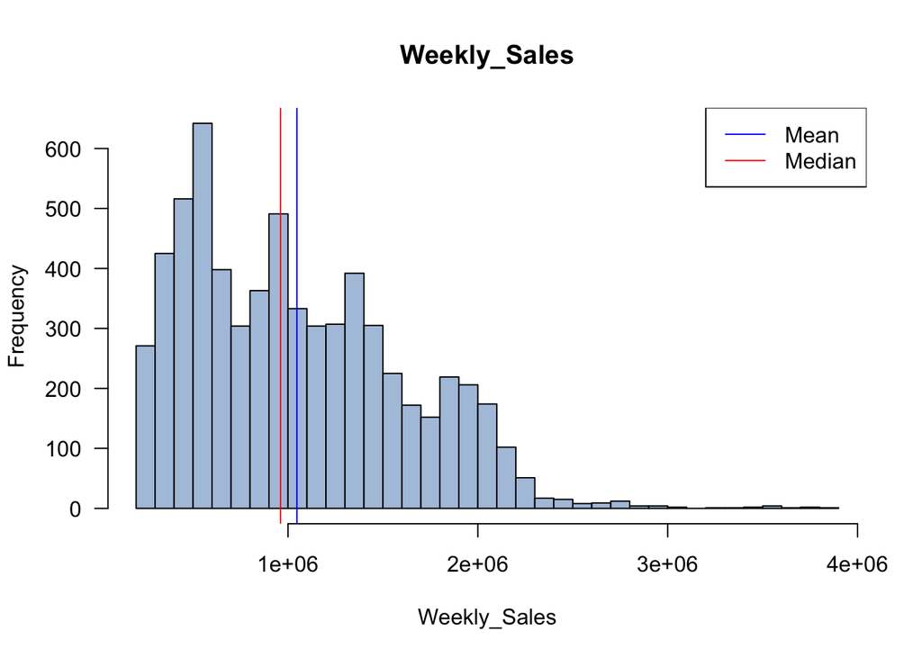

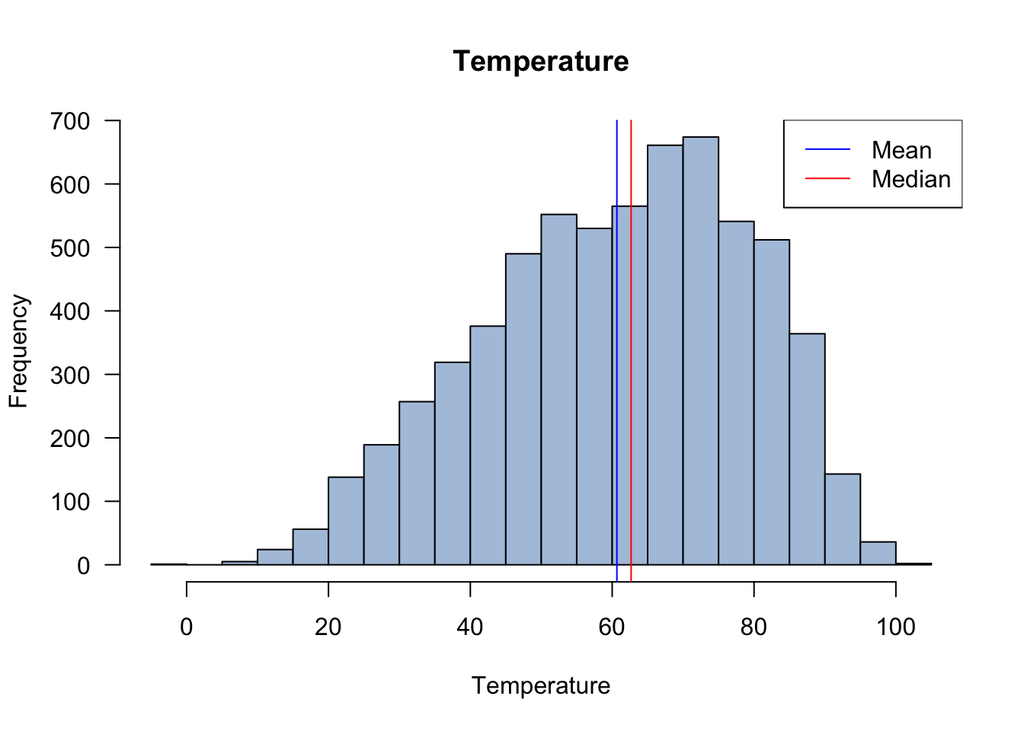

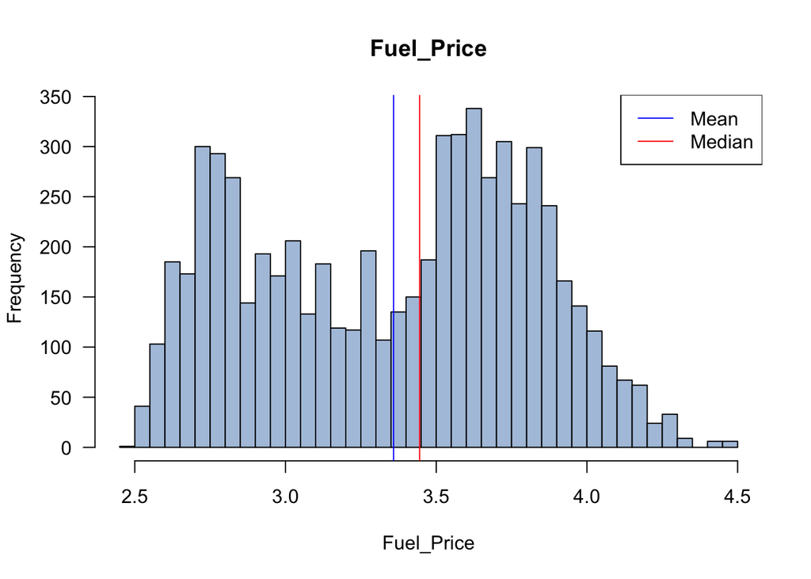

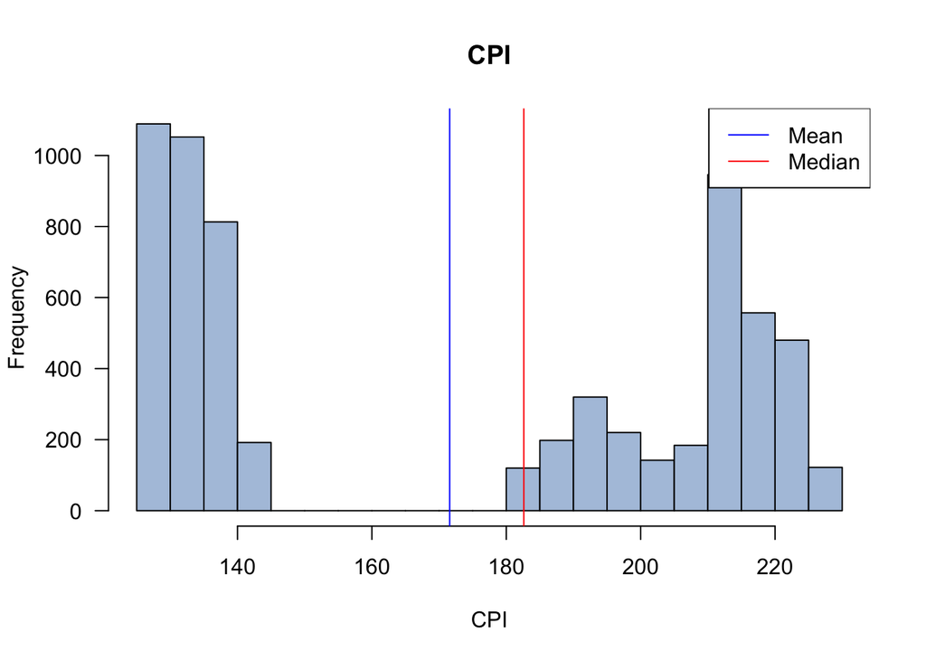

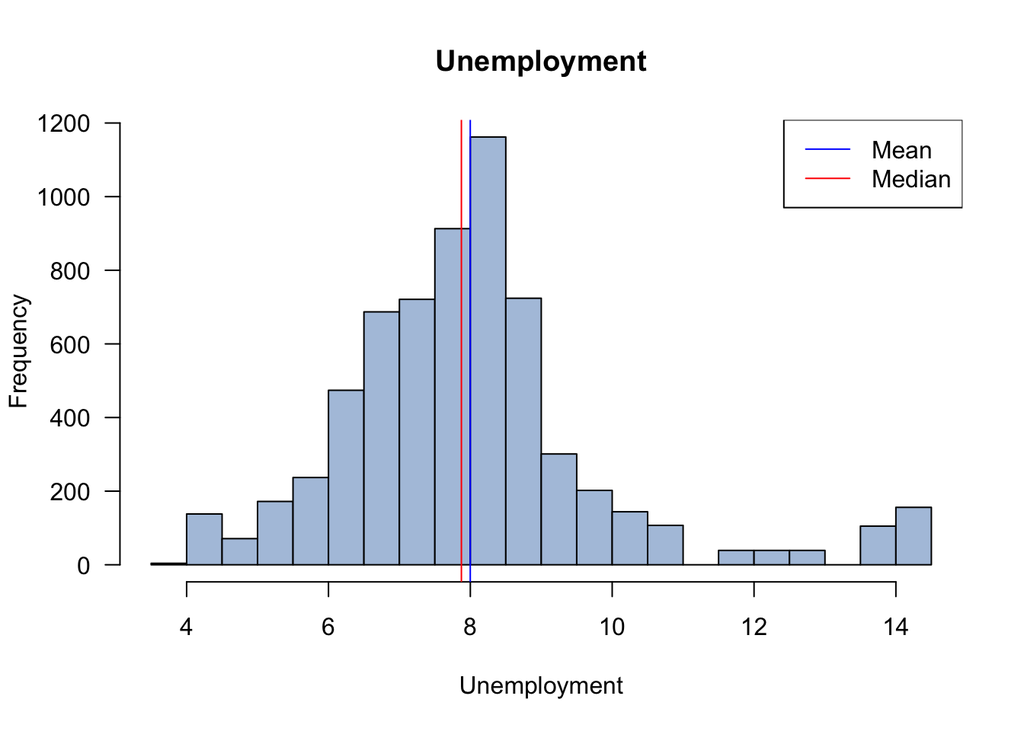

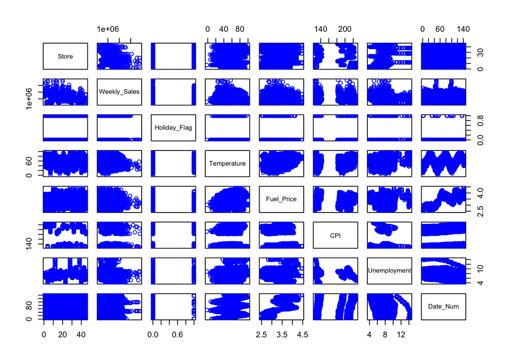

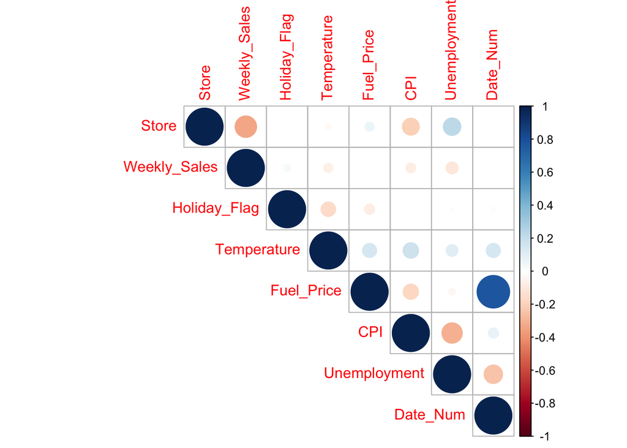

By taking a quick glase at the relationships of each variable, we can see that most of the relationships are weak or moderate. The biggest correlation seems to be Fuel_Price and the date, as the dates go futher into the future, the fuel price seems to rise.

|  | Store | Date | Weekly_Sales | Holiday_Flag | Temperature | Fuel_Price | CPI | Unemployment |
| --- | --- | --- | --- | --- | --- | --- | --- | --- |
| 1906 | 14 | 2010-12-24 | 3818686 | 0 | 30.59 | 3.141 | 182.5446 | 8.724 |
| 2764 | 20 | 2010-12-24 | 3766687 | 0 | 25.17 | 3.141 | 204.6377 | 7.484 |
| 1334 | 10 | 2010-12-24 | 3749058 | 0 | 57.06 | 3.236 | 126.9836 | 9.003 |
| 528 | 4 | 2011-12-23 | 3676389 | 0 | 35.92 | 3.103 | 129.9845 | 5.143 |
| 1763 | 13 | 2010-12-24 | 3595903 | 0 | 34.90 | 2.846 | 126.9836 | 7.795 |
| 1815 | 13 | 2011-12-23 | 3556766 | 0 | 24.76 | 3.186 | 129.9845 | 6.392 |

|  | Store | Date | Weekly_Sales | Holiday_Flag | Temperature | Fuel_Price | CPI | Unemployment |
| --- | --- | --- | --- | --- | --- | --- | --- | --- |
| 4620 | 33 | 2010-12-03 | 209986.2 | 0 | 52.82 | 3.041 | 126.7313 | 9.265 |
| 4615 | 33 | 2010-10-29 | 213538.3 | 0 | 71.34 | 3.130 | 126.4364 | 9.265 |
| 4676 | 33 | 2011-12-30 | 215359.2 | 1 | 51.60 | 3.428 | 130.0710 | 8.010 |
| 4624 | 33 | 2010-12-31 | 219804.9 | 1 | 52.91 | 3.148 | 127.0877 | 9.265 |
| 4672 | 33 | 2011-12-02 | 220060.4 | 0 | 59.12 | 3.701 | 129.8460 | 8.010 |
| 4606 | 33 | 2010-08-27 | 224031.2 | 0 | 94.00 | 3.022 | 126.0893 | 9.495 |

```r
# Dataset from sql, The averages grouped by stores, (Note: Date is taken out)
Store_Avgs <- read.csv("~/Documents/Data Science/DSA_8660/Capstone/Store_Avgs.csv")

# Overall average weekly sales is $1,046,965 per store
mean(Store_Avgs$Avg_Weekly_Sales)
```

```
## [1] 1046965
```

```r
# Store 20, 4, 14, 13, 2 performed best on average over all weeks in the dataset
head(Store_Avgs[order(-Store_Avgs$Avg_Weekly_Sales),])
```

|  | Store | Avg_Weekly_Sales | Avg_Temp | Avg_Fuel_Price | Avg_CPI | Avg_Unemployment |
| --- | --- | --- | --- | --- | --- | --- |
| 1 | 20 | 2107677 | 55.45 | 3.42 | 209.04 | 7.37 |
| 2 | 4 | 2094713 | 62.25 | 3.22 | 128.68 | 5.96 |
| 3 | 14 | 2020978 | 57.79 | 3.42 | 186.29 | 8.65 |
| 4 | 13 | 2003620 | 53.70 | 3.29 | 128.68 | 7.00 |
| 5 | 2 | 1925751 | 68.22 | 3.22 | 215.65 | 7.62 |
| 6 | 10 | 1899425 | 72.24 | 3.58 | 128.68 | 8.36 |

```r
# Store 33, 44, 5 36, 38 performed the worst on average over all weeks in the dataset
head(Store_Avgs[order(Store_Avgs$Avg_Weekly_Sales),])
```

|  | Store | Avg_Weekly_Sales | Avg_Temp | Avg_Fuel_Price | Avg_CPI | Avg_Unemployment |
| --- | --- | --- | --- | --- | --- | --- |
| 45 | 33 | 259861.7 | 76.73 | 3.58 | 128.68 | 8.53 |
| 44 | 44 | 302748.9 | 53.70 | 3.29 | 128.68 | 6.74 |
| 43 | 5 | 318011.8 | 69.41 | 3.22 | 216.57 | 6.30 |
| 42 | 36 | 373512.0 | 71.16 | 3.20 | 214.73 | 7.87 |
| 41 | 38 | 385731.7 | 70.26 | 3.61 | 128.68 | 13.12 |
| 40 | 3 | 402704.4 | 71.43 | 3.22 | 219.39 | 7.18 |

The next dataset I looked at was one created from MySQL Workbench where I selected the averages of each of the variables (minus date and holiday flag) grouped by stores. This new dataset allowed me to determine that the overall mean of weekly sales is 1,046,965 dollars. Also, I was able to determine the best performing stores on average along with the worst. As shown in the datasets, by ordering them by increasing and decreasing order of average weekly sales (), it is clear that stores 20, 4, 14, 13, and 2 performed best on average over all weeks in the dataset. Also, stores 33, 44, 5 36, and 38 performed the worst on average over all weeks in the dataset.

```r
# Using dplyr library to filter dataset
library(dplyr)
```

```
##  [1]  1  3  4  5  7  8  9 11 12 13 16 17 20 23 25 26 31 32 34 37 38 39 40 41 42
## [26] 44
```

```
## [1] 0.06100162
```

```
## [1] -0.9424812  0.8041051
```

```
## [1] 38
```

```
## [1] 36
```

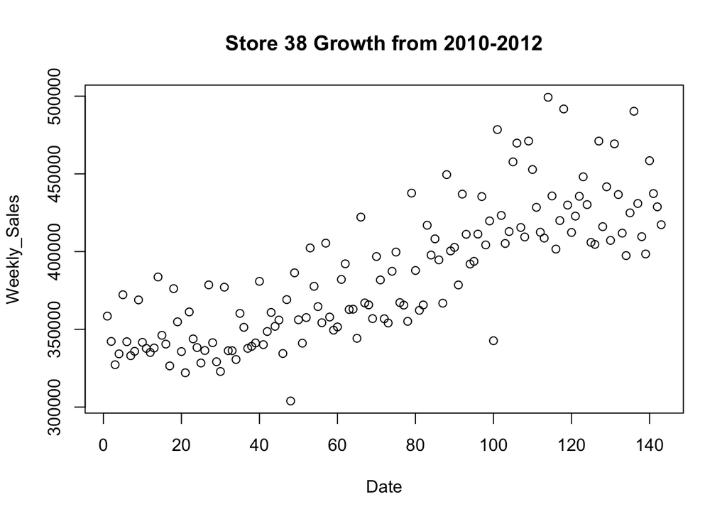

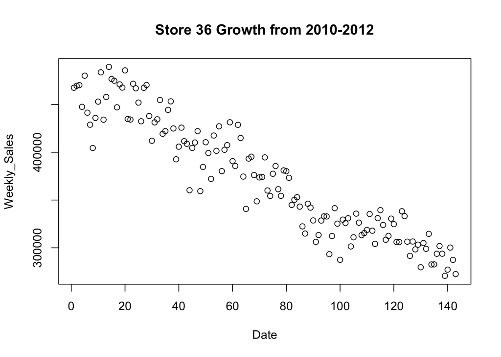

In order to determine which stores had positive overall weekly sales growth over the dates, I looped over all 45 stores and took the correlation from the and . By creating a dummy object called Store_Yearly_Growth, giving it 45 values of 0, I was able to take the correlations from each store and set those values to the observations of Store_Yearly_Growth. From this new object, I was able to see that there were 26 stores that had greater than or equal to 0 growth over the span of the dataset. Thus leaving 19 stores that had negative growth over the span of the dataset. To give a visual, I created plots over the dates for the most improved store, 38, and the store with the most negative growth, 36.

```r
Holiday_Nonholiday_Avgs <- read.csv("~/Documents/Data Science/DSA_8660/Capstone/Holiday_Nonholiday_Avgs.csv")

# Store 20, 4, 14, 10, 13 have the best weekly sales on average for holidays
head(Holiday_Nonholiday_Avgs[order(-Holiday_Nonholiday_Avgs$Holiday_Weekly_Sales),])
```

|  | Store | Holiday_Weekly_Sales | Holiday_Temp | Holiday_Fuel_Price | Holiday_CPI | Holiday_Unemployment | Store.1 | NonHoliday_Weekly_Sales | NonHoliday_Temp | NonHoliday_Fuel_Price | NonHoliday_CPI | NonHoliday_Unemployment |
| --- | --- | --- | --- | --- | --- | --- | --- | --- | --- | --- | --- | --- |
| 1 | 20 | 2249035 | 44.93 | 3.31 | 208.60 | 7.37 | 20 | 2097048 | 56.24 | 3.43 | 209.07 | 7.37 |
| 2 | 4 | 2243103 | 49.51 | 3.09 | 128.48 | 6.14 | 4 | 2083556 | 63.21 | 3.23 | 128.69 | 5.95 |
| 3 | 14 | 2120583 | 47.54 | 3.31 | 185.90 | 8.65 | 14 | 2013489 | 58.56 | 3.43 | 186.31 | 8.65 |
| 6 | 10 | 2113756 | 62.80 | 3.43 | 128.48 | 8.44 | 10 | 1883309 | 72.95 | 3.59 | 128.69 | 8.36 |
| 4 | 13 | 2113044 | 42.97 | 3.13 | 128.48 | 7.09 | 13 | 1995393 | 54.50 | 3.30 | 128.69 | 7.00 |
| 5 | 2 | 2079267 | 57.46 | 3.09 | 215.19 | 7.71 | 2 | 1914209 | 69.03 | 3.23 | 215.68 | 7.62 |

```r
# Store 20, 4, 14, 13, 2 have the best weekly sales on average for non holidays
head(Holiday_Nonholiday_Avgs[order(-Holiday_Nonholiday_Avgs$NonHoliday_Weekly_Sales),])
```

|  | Store | Holiday_Weekly_Sales | Holiday_Temp | Holiday_Fuel_Price | Holiday_CPI | Holiday_Unemployment | Store.1 | NonHoliday_Weekly_Sales | NonHoliday_Temp | NonHoliday_Fuel_Price | NonHoliday_CPI | NonHoliday_Unemployment |
| --- | --- | --- | --- | --- | --- | --- | --- | --- | --- | --- | --- | --- |
| 1 | 20 | 2249035 | 44.93 | 3.31 | 208.60 | 7.37 | 20 | 2097048 | 56.24 | 3.43 | 209.07 | 7.37 |
| 2 | 4 | 2243103 | 49.51 | 3.09 | 128.48 | 6.14 | 4 | 2083556 | 63.21 | 3.23 | 128.69 | 5.95 |
| 3 | 14 | 2120583 | 47.54 | 3.31 | 185.90 | 8.65 | 14 | 2013489 | 58.56 | 3.43 | 186.31 | 8.65 |
| 4 | 13 | 2113044 | 42.97 | 3.13 | 128.48 | 7.09 | 13 | 1995393 | 54.50 | 3.30 | 128.69 | 7.00 |
| 5 | 2 | 2079267 | 57.46 | 3.09 | 215.19 | 7.71 | 2 | 1914209 | 69.03 | 3.23 | 215.68 | 7.62 |
| 6 | 10 | 2113756 | 62.80 | 3.43 | 128.48 | 8.44 | 10 | 1883309 | 72.95 | 3.59 | 128.69 | 8.36 |

```r
# Store 33, 44, 5, 36, 38 have the worst weekly sales on average for holidays
head(Holiday_Nonholiday_Avgs[order(Holiday_Nonholiday_Avgs$Holiday_Weekly_Sales),])
```

|  | Store | Holiday_Weekly_Sales | Holiday_Temp | Holiday_Fuel_Price | Holiday_CPI | Holiday_Unemployment | Store.1 | NonHoliday_Weekly_Sales | NonHoliday_Temp | NonHoliday_Fuel_Price | NonHoliday_CPI | NonHoliday_Unemployment |
| --- | --- | --- | --- | --- | --- | --- | --- | --- | --- | --- | --- | --- |
| 45 | 33 | 262594.5 | 67.25 | 3.43 | 128.48 | 8.63 | 33 | 259656.2 | 77.44 | 3.59 | 128.69 | 8.53 |
| 44 | 44 | 296035.6 | 42.97 | 3.13 | 128.48 | 6.83 | 44 | 303253.6 | 54.50 | 3.30 | 128.69 | 6.73 |
| 43 | 5 | 359501.6 | 59.53 | 3.09 | 216.11 | 6.39 | 5 | 314892.3 | 70.15 | 3.23 | 216.60 | 6.29 |
| 42 | 36 | 367640.6 | 61.98 | 3.07 | 214.28 | 7.97 | 36 | 373953.5 | 71.85 | 3.21 | 214.76 | 7.86 |
| 41 | 38 | 381509.9 | 60.28 | 3.45 | 128.48 | 13.32 | 38 | 386049.1 | 71.01 | 3.62 | 128.69 | 13.10 |
| 39 | 30 | 436859.3 | 57.72 | 3.09 | 215.19 | 7.71 | 30 | 438709.0 | 69.68 | 3.23 | 215.68 | 7.62 |

```r
# Store 33, 44, 5, 36, 38 have the worst weekly sales on average for non holidays
head(Holiday_Nonholiday_Avgs[order(Holiday_Nonholiday_Avgs$NonHoliday_Weekly_Sales),])
```

|  | Store | Holiday_Weekly_Sales | Holiday_Temp | Holiday_Fuel_Price | Holiday_CPI | Holiday_Unemployment | Store.1 | NonHoliday_Weekly_Sales | NonHoliday_Temp | NonHoliday_Fuel_Price | NonHoliday_CPI | NonHoliday_Unemployment |
| --- | --- | --- | --- | --- | --- | --- | --- | --- | --- | --- | --- | --- |
| 45 | 33 | 262594.5 | 67.25 | 3.43 | 128.48 | 8.63 | 33 | 259656.2 | 77.44 | 3.59 | 128.69 | 8.53 |
| 44 | 44 | 296035.6 | 42.97 | 3.13 | 128.48 | 6.83 | 44 | 303253.6 | 54.50 | 3.30 | 128.69 | 6.73 |
| 43 | 5 | 359501.6 | 59.53 | 3.09 | 216.11 | 6.39 | 5 | 314892.3 | 70.15 | 3.23 | 216.60 | 6.29 |
| 42 | 36 | 367640.6 | 61.98 | 3.07 | 214.28 | 7.97 | 36 | 373953.5 | 71.85 | 3.21 | 214.76 | 7.86 |
| 41 | 38 | 381509.9 | 60.28 | 3.45 | 128.48 | 13.32 | 38 | 386049.1 | 71.01 | 3.62 | 128.69 | 13.10 |
| 40 | 3 | 437811.0 | 62.89 | 3.09 | 218.93 | 7.25 | 3 | 400064.8 | 72.08 | 3.23 | 219.43 | 7.17 |

After finding the store growths, I then went on to determine which stores performed best/worst on holidays and non-holidays. In order to do this, I created a new dataset called which gives the average values, like Store_Avgs, for each variable, but for holidays and non-holidays seperated. As seen in the datasets above, by sorting the new dataset by decreasing and increasing holiday weekly sales, we are able to see that stores 20, 4, 14, 10, and 13 have the best weekly sales on average for holidays and stores 33, 44, 5, 36, and 38 have the worst weekly sales on average for holidays. Then, by sorting the non-holiday weekly sales, I was able to conclude that stores 20, 4, 14, 13, and 2 have the best weekly sales on average for non-holidays and stores 33, 44, 5, 36, and 38 have the worst weekly sales on average for non-holidays. It is somewhat clear that the same stores have the best and worst performances for either holiday weeks or non-holiday weeks so I will look more closely at the diffferences between the two categories of weeks.

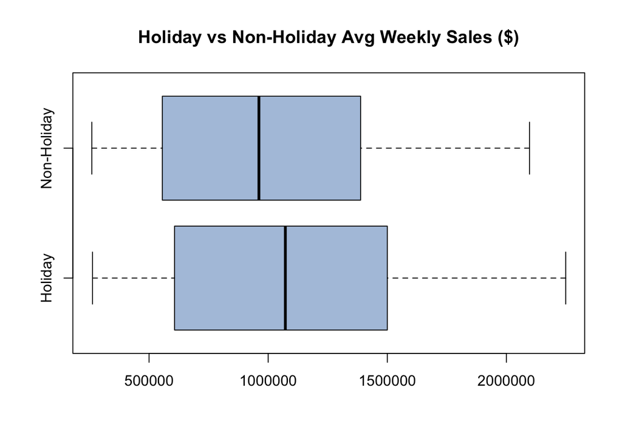

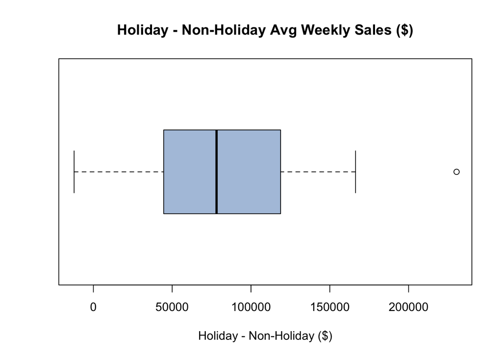

By comparing the holiday weeks to the non-holiday weeks with side-by-side boxplots, we can see that on average, the holiday weeks have greater sales than the non-holiday weeks. Also, we can see that the ranges are pretty similar. By taking a look at the differences (holiday - non-holiday average weekly sales) between the two sets of weeks, we can see that their is an outlier above 200,000 and the mean difference is around 80,000. We can also see that there are some negative differences, meaning some stores have, on average, worse performances during the holidays.

```
## [1] 37 39 41 42 44
```

```
## [1] 230446.5
```

```
## [1] 6
```

|  | Store | Holiday_Weekly_Sales | Holiday_Temp | Holiday_Fuel_Price | Holiday_CPI | Holiday_Unemployment | Store.1 | NonHoliday_Weekly_Sales | NonHoliday_Temp | NonHoliday_Fuel_Price | NonHoliday_CPI | NonHoliday_Unemployment | diff |
| --- | --- | --- | --- | --- | --- | --- | --- | --- | --- | --- | --- | --- | --- |
| 6 | 10 | 2113756 | 62.8 | 3.43 | 128.48 | 8.44 | 10 | 1883309 | 72.95 | 3.59 | 128.69 | 8.36 | 230446.5 |

```
## [1] 89105.69
```

```
## [1] 45438.25
```

Taking a closer look at the differences in holiday vs non-holiday average weekly sales, we are able to see that stores 37, 39, 41, 42, and 44 perform worse on average during holiday weeks than non holiday weeks. Also, store 10 has the greatest difference in holiday sales vs non holiday sales with a difference of 230,446. To examine this further, I decided to take out the stores with negative differences. By doing this, I was able to determine that for positive differences in weekly averages of holidays vs non holidays the mean difference is 89,105.69 and the standard deviation is 45,438.25. This means on average, for stores with greater holiday sales, the difference in sales is 89,105.69.

After this analysis, I decided to take a closer look at the individual holiday weeks by creating new datasets in MySQL Workbench and importing them into RStudio as follows:

```r
SuperBowl_Sales <- read.csv("~/Documents/Data Science/DSA_8660/Capstone/SuperBowl_Sales.csv")
LabourDay_Sales <- read.csv("~/Documents/Data Science/DSA_8660/Capstone/LabourDay_Sales.csv")
Thanksgiving_Sales <- read.csv("~/Documents/Data Science/DSA_8660/Capstone/Thanksgiving_Sales.csv")
Christmas_Sales <- read.csv("~/Documents/Data Science/DSA_8660/Capstone/Christmas_Sales.csv")
```

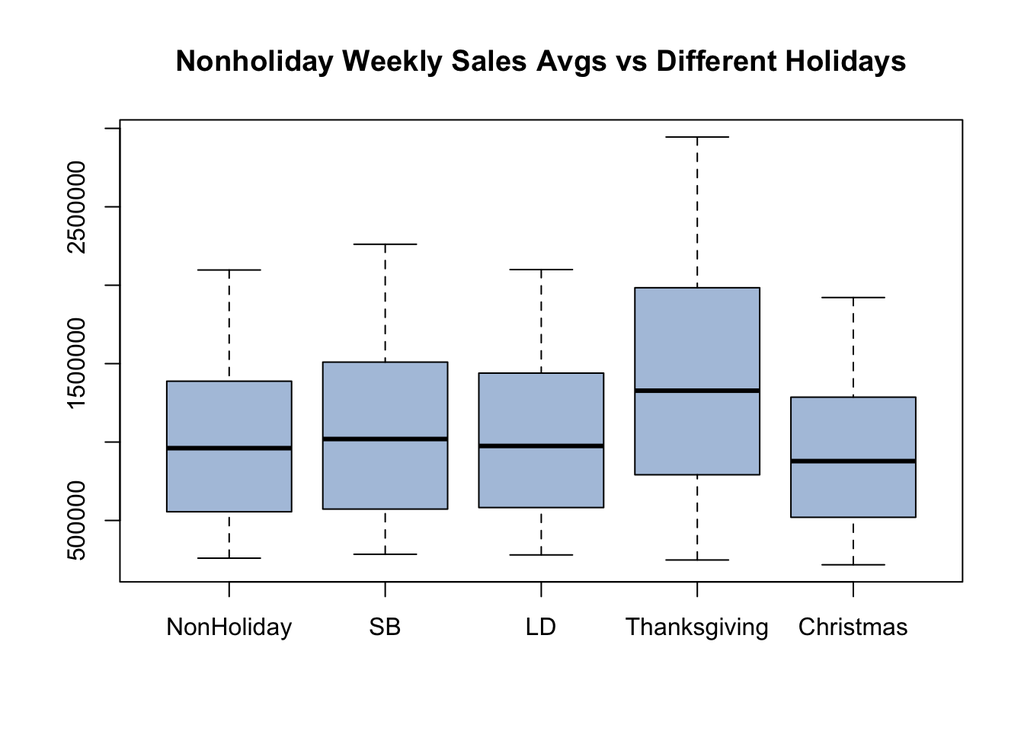

By creating a side-by-side boxplots of the store averages for each store during the different holiday weeks vs non-holiday weeks we are able to see that the best holiday in terms of average weekly sales per store is during thanksgiving. The Superbowl has the second largest average weekly sales for holidays, then comes Labour Day, then Christmas. Oddly enough, the Christmas week is less than non-holiday weeks on average. Also, it is good to note that all of the holidays have around the same variances, with the exception of Thanksgiving.

After seeing these differences, I decided to take it a step further and look at the holiday averages in comparison with the average weekly sales of the month that the holidays reside in. Again, I created new datasets in MySQL Workbench and transferred them to RStudio as follows:

```r
Feb_vs_SB <- read.csv("~/Documents/Data Science/DSA_8660/Capstone/Feb_vs_SB.csv")
Sep_vs_LD <- read.csv("~/Documents/Data Science/DSA_8660/Capstone/Sep_vs_LD.csv")
Nov_vs_TG <- read.csv("~/Documents/Data Science/DSA_8660/Capstone/Nov_vs_TG.csv")
Dec_vs_Christmas <- read.csv("~/Documents/Data Science/DSA_8660/Capstone/Dec_vs_Christmas.csv")
```

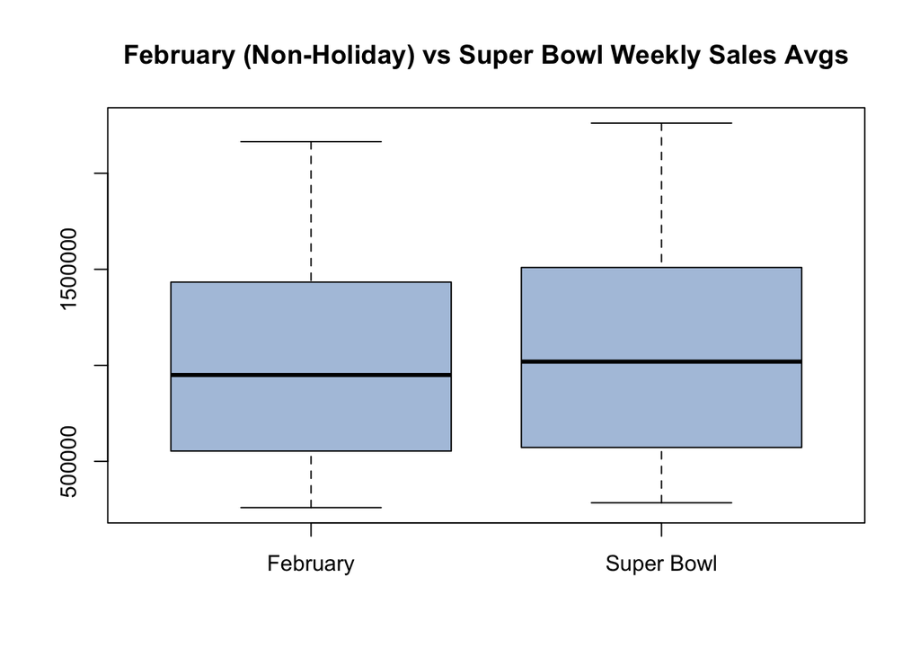

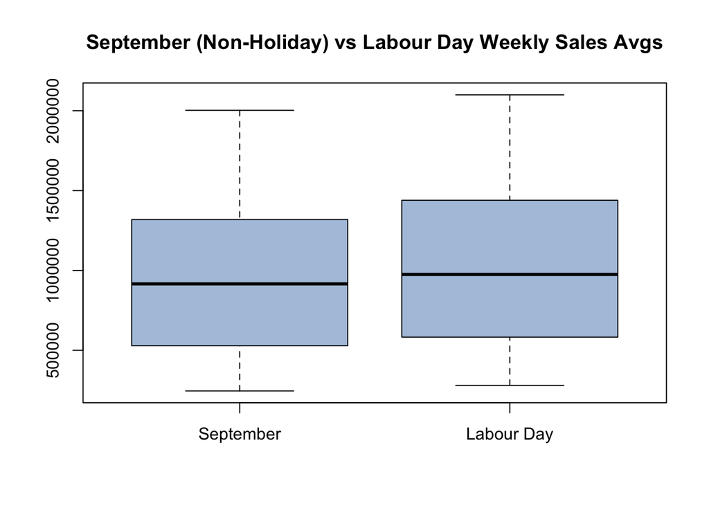

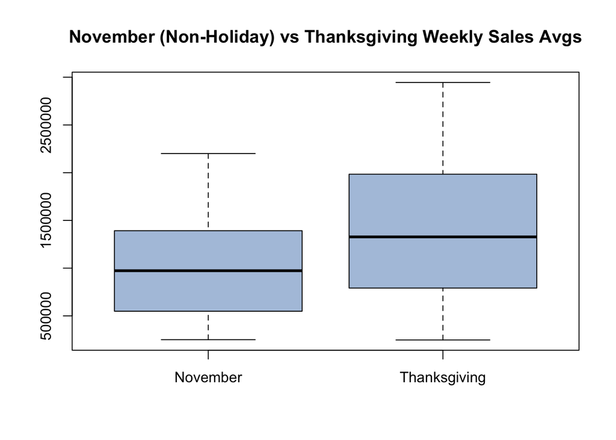

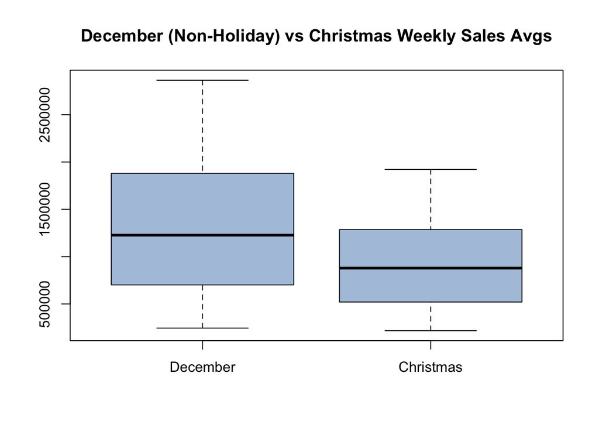

As shown in the boxplots above, on average, the stores have greater weekly sales averages on holiday weeks, except for Christmas, than the non-holiday weeks in the months that they reside in.

After looking at the questions of interest, I decided to take a look at the other variables in the *Walmart* dataset to see if they had an relationship with weekly sales of a given store. Using the Store_Avgs dataset again, we can see the following:

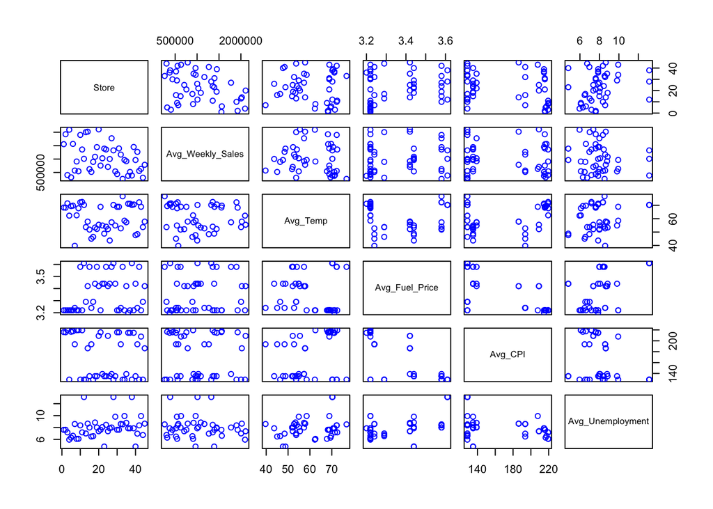

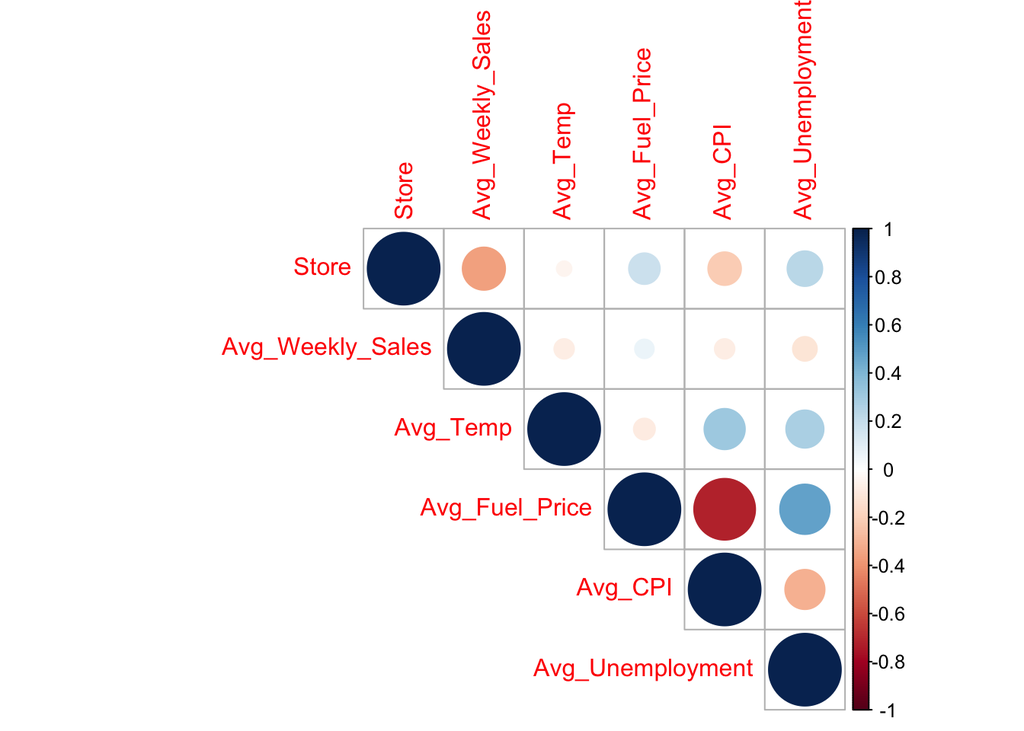

As seen in the plots, and correlation matrix, there is not much of a relationship between the average weekly sales and the other variables.

# 6 Final Results and Suggestions

By analyzing the *Walmart* dataset using MySQL Workbench to create datasets, and RStudio to visualize/analyze the datasets, I was able to determine that stores 20, 4, 14, 13, and 2 performed best on average over all weeks in the dataset. Also, stores 33, 44, 5 36, and 38 performed the worst on average over all weeks in the dataset.

Next, I was also able to determine that on average, the holiday weeks have greater sales than the non-holiday weeks with a mean difference of around 80,000 dollars. Note that stores 37, 39, 41, 42, and 44 perform worse on average during holiday weeks than non holiday weeks. As we can see, store 44 has a poor performance for overall weekly averages as well as holiday weekly averages. In addition, I was able to determine that store 10 has the greatest difference in holiday sales vs non holiday sales with a difference of 230,446. By taking a closer look at the stores with positive differences in holiday vs non-holiday weekly sales I was able to determine that on average the difference in average weekly sales is 89,105.69.

Another result from the analysis is that there were 26 stores that had greater than or equal to 0 growth over the span of the dataset. Thus leaving 19 stores that had negative growth over the span of the dataset. To recall, the I the most improved store was store 38, and the store with the most negative growth is store 36. From this result, we know that store 38 was one of the worst performing stores for average weekly sales, however, we now know that they grew their average weekly sales the most over the span of the 143 weeks. Also, store 36 was one of the worst performing stores for average weekly sales with the largest descrease in sales over the 143 weeks.

In addition to these results, I was able to determine that on average the stores have greater weekly sales on all of the holiday weeks than the non-holiday weeks in the months that they reside in, except for Christmas.

Lastly, looking at the correlation matrix of the variables and their relationship to average weekly sales, it was clear that there is not much of a relationship between the average weekly sales and the other variables.

Knowing this information, I would, first, suggest that Walmart take note of the stores that generate less weekly sales on average and either promote the brand with good deals in that area to gain more loyal customers, or to carry less supply in those stores to reduce costs. Second, I would suggest that for all of the stores that performed better on average during the holiday weeks than non-holiday weeks, to either carry 80,000 dollars worth of supplies since it was the average difference, or to carry the same amount of supplies in those stores as previous years with some additional supplies depending on the store and their past sales. Next, I would suggest that Walmart begins to take note of the 19 stores that are trending in decreasing average weekly sales over time and take action with respect to marketing in order to have postive trending weekly sales. Lastly, I would suggest that all of the stores carry an excess of at least 50,000 dollars worth of supplies for the weeks of late November and early December, since it is easy to see that this period generates the greatest weekly sales throughout the year. I suggested this number because as shown in the “Nonholiday Weekly Sales Avgs vs Different Holidays” table, Thanksgiving sales and early December sales look to be on average of above 50,000 dollars more in sales than regular non-holiday weeks.